# Psych 254 W15 PS #2

MH Tessler

February 9, 2015

This is problem set #2, in which we hope you will practice the visualization package ggplot2, as well as hone your knowledge of the packages tidyr and dplyr.

# Part 1: Basic intro to ggplot

## Part 1A: Exploring ggplot2 using qplot

Note, that this example is from the_grammar.R on http://had.co.nz/ggplot2 I’ve adapted this for psych 254 purposes

First install and load the package.

```r
#install.packages("ggplot2")
#library(ggplot2)
```

Now we’re going to use qplot. qplot is the easy interface, meant to replace plot. You can give it simple `qplot(x,y)` examples, or slightly more complex examples like `qplot(x, y, col=grp, data=d)`.

We’re going to be using the diamonds dataset. This is a set of measurements of diamonds, along with their price etc.

```r
head(diamonds)
```

```
##   carat       cut color clarity depth table price    x    y    z
## 1  0.23     Ideal     E     SI2  61.5    55   326 3.95 3.98 2.43
## 2  0.21   Premium     E     SI1  59.8    61   326 3.89 3.84 2.31
## 3  0.23      Good     E     VS1  56.9    65   327 4.05 4.07 2.31
## 4  0.29   Premium     I     VS2  62.4    58   334 4.20 4.23 2.63
## 5  0.31      Good     J     SI2  63.3    58   335 4.34 4.35 2.75
## 6  0.24 Very Good     J    VVS2  62.8    57   336 3.94 3.96 2.48
```

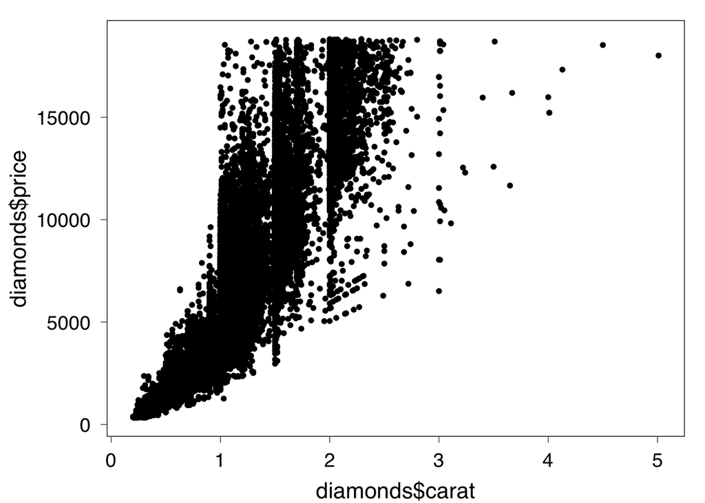

```r
qplot(diamonds$carat, diamonds$price)
```

Scatter plots are trivial, and easy to add features to. Modify this plot so that it uses the dataframe rather than working from variables in the general namespace (good to get away from retyping `diamonds$` every time you reference a variable).

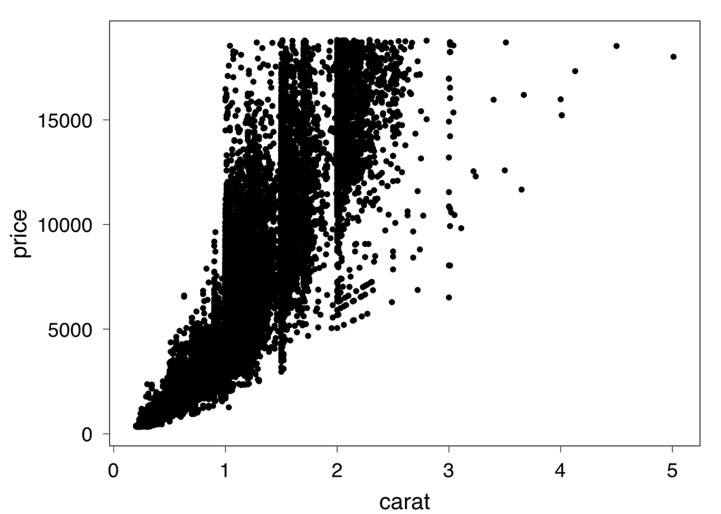

```r
qplot(data=diamonds, x = carat, y = price)
```

Try adding clarity and cut, using shape and color as your visual variables.

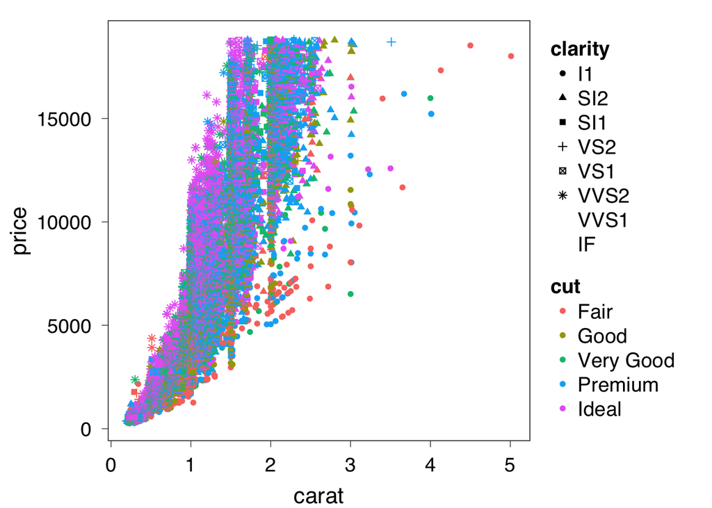

```r
qplot(data=diamonds, x = carat, y = price, shape = clarity, color = cut)
```

One of the primary benefits of `ggplot2` is the use of facets - also known as small multiples in the Tufte vocabulary. That last plot was probably hard to read. Facets could make it better. Try adding a `facets = x ~ y` argument. `x ~ y` means row facets are by x, column facets by y.

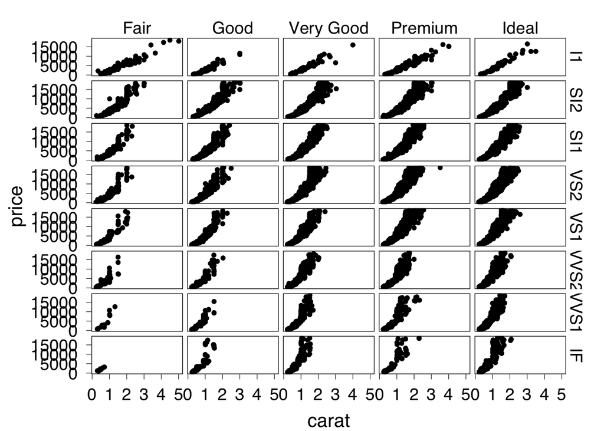

```r
qplot(data = diamonds, x= carat, y = price, facets = clarity ~ cut)
```

But facets can also get overwhelming. Try to strike a good balance between color, shape, and faceting.

HINT: `facets = . ~ x` puts x on the columns, but `facets = ~ x` (no dot) *wraps* the facets. These are underlying calls to different functions, `facet_wrap` (no dot) and `facet_grid` (two arguments).

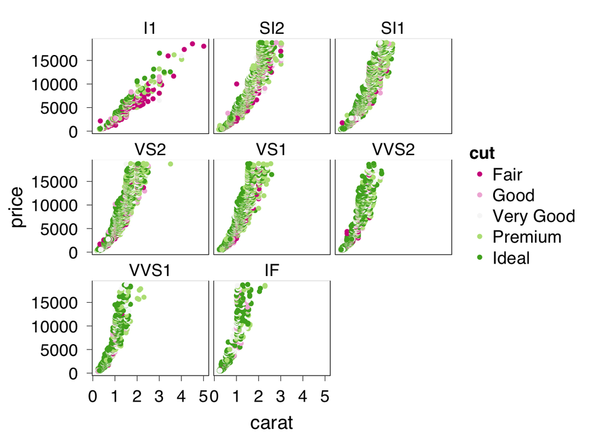

```r
qplot(data = diamonds, x =carat, y = price, facets = ~clarity, color = cut)+
  scale_color_brewer(palette = 2, type = 'div')
```

The basic unit of a ggplot plot is a “geom” - a mapping between data (via an “aesthetic”) and a particular geometric configuration on coordinate axes.

Let’s try some other geoms and manipulate their parameters. First, try a histogram (`geom="hist"`).

```
## stat_bin: binwidth defaulted to range/30. Use 'binwidth = x' to adjust this.
```

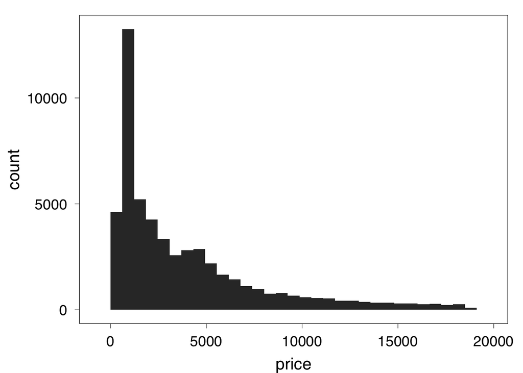

```r
qplot(data = diamonds, x = price, geom="histogram")
```

Now facet your histogram by clarity and cut.

[output not shown]

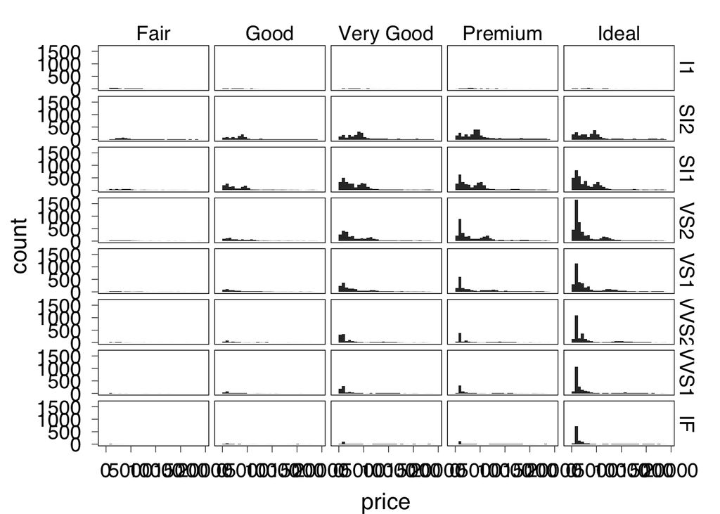

```r
qplot(data = diamonds, x = price, geom="histogram", facets = clarity~cut)
```

I like a slightly cleaner look to my plots. Luckily, ggplot allows you to add “themes” to your plots. Try doing the same plot but adding `+ theme_bw()` or `+ theme_classic()`. Different themes work better for different applications, in my experience.

[output not shown]

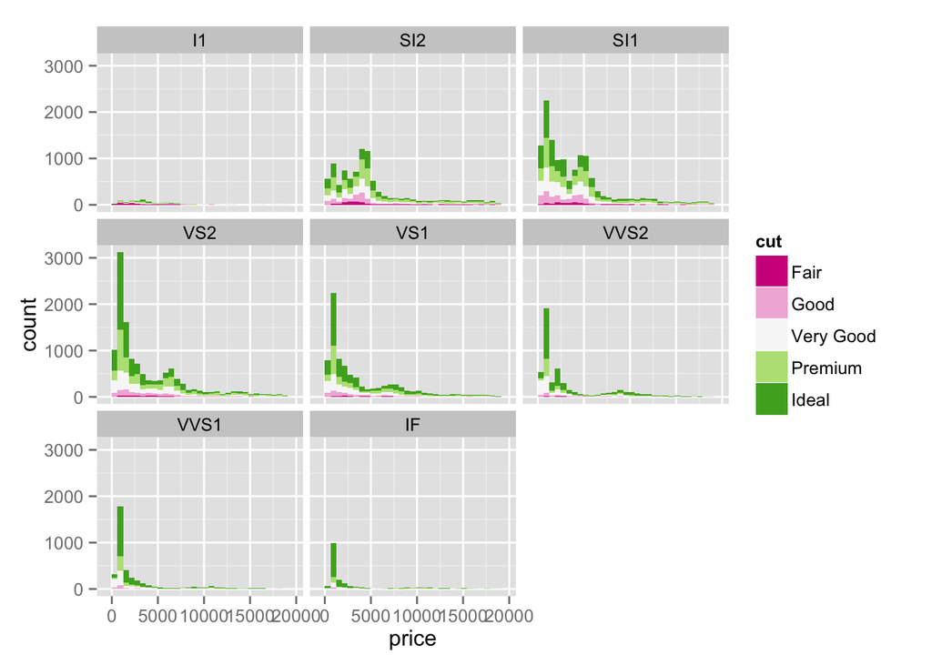

```r
qplot(data = diamonds, x =price, facets = ~clarity, fill = cut)+
  scale_fill_brewer(palette = 2, type = 'div')+
  theme_grey()
```

## Part 1B: Exploring ggplot2 using ggplot

`ggplot` is just a way of building `qplot` calls up more systematically. It’s sometimes easier to use and sometimes a bit more complicated. What I want to show off here is the functionality of being able to build up complex plots with multiple elements. You can actually do this using qplot pretty easily, but there are a few things that are hard to do.

`ggplot` is the basic call, where you specify A) a dataframe and B) an aesthetic mapping from variables in the plot space to variables in the dataset.

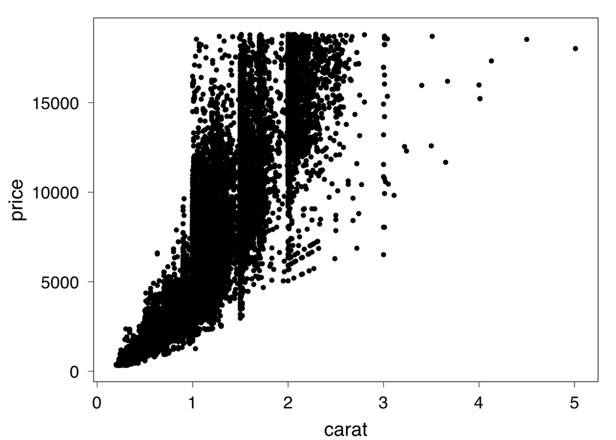

```r
d <- ggplot(diamonds, aes(x=carat, y=price)) # first you set the aesthetic and dataset
d + geom_point() # then you add geoms
```

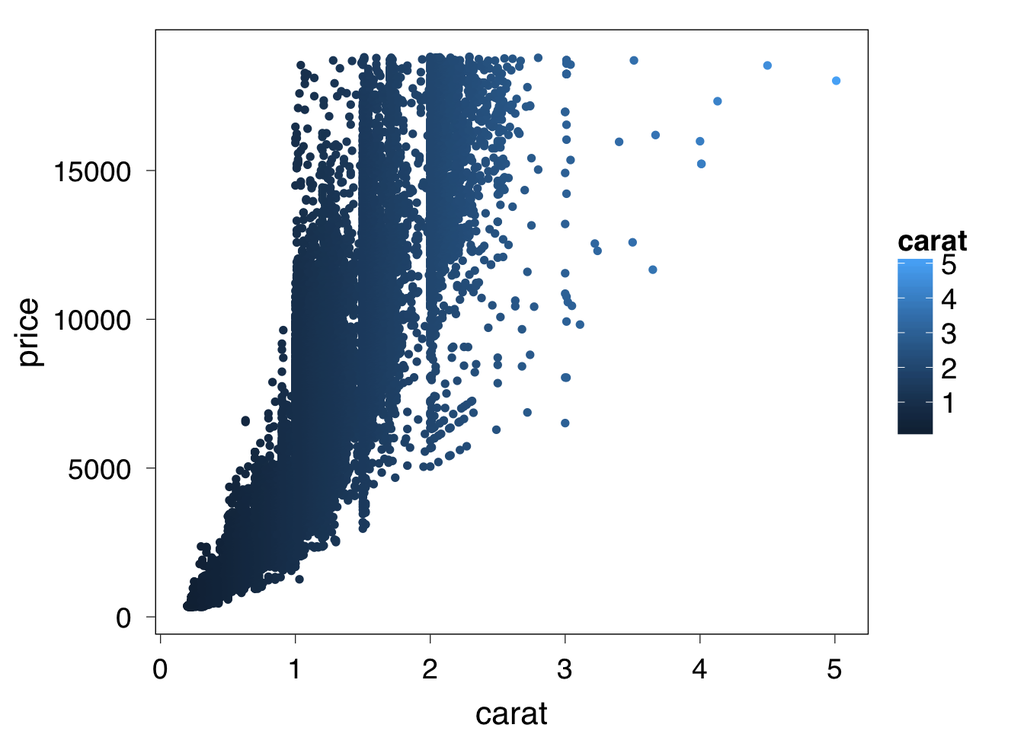

```r
d + geom_point(aes(colour = carat)) # and you can keep doing this to add layers to the plot
```

Try writing this as a single set of additions (e.g. one line of R code, though you can put in linebreaks). This is the most common workflow for me.

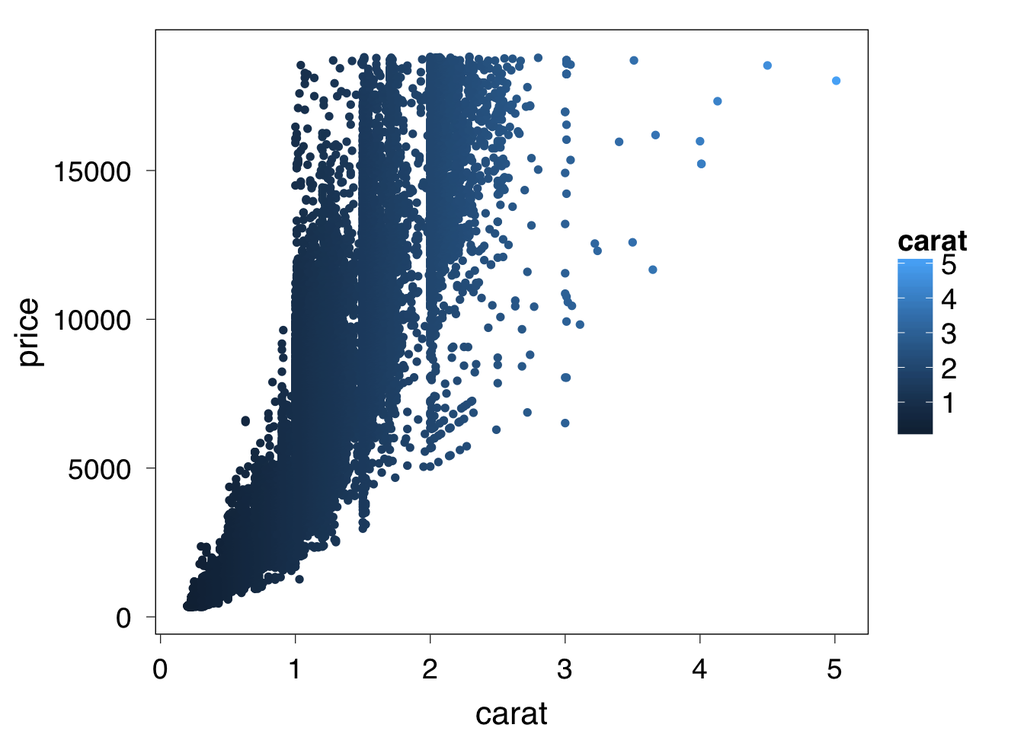

```r
ggplot(diamonds, aes(x = carat, y = price, colour = carat))+
  geom_point()
```

You can also set the aesthetic separately for each geom, and make some great plots this way. Though this can get complicated. Try using `ggplot` to build a histogram of prices.

```
## stat_bin: binwidth defaulted to range/30. Use 'binwidth = x' to adjust this.
```

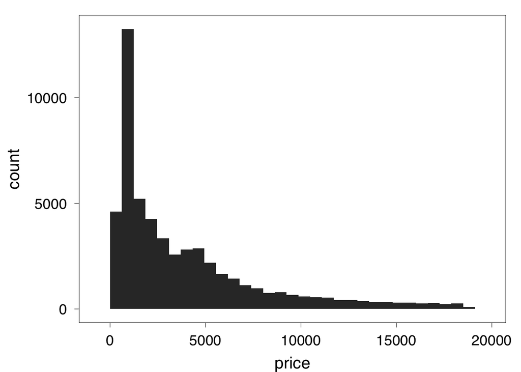

```r
ggplot(diamonds, aes(x=price))+
  geom_histogram()
```

# Part 2: Diving into real data: Sklar et al. (2012)

Sklar et al. (2012) claims evidence for unconscious arithmetic processing. We’re going to do a reanalysis of their Experiment 6, which is the primary piece of evidence for that claim. The data are generously contributed by Asael Sklar.

First let’s set up a few preliminaries.

```r
library(tidyr)
library(dplyr)

sem <- function(x) {sd(x) / sqrt(length(x))}
ci95 <- function(x) {sem(x) * 1.96}
```

## Data Prep

First read in two data files and subject info. A and B refer to different trial order counterbalances.

```r
setwd("~/Documents/class/15.1/psych254_materials/analyses")
subinfo <- read.csv("../data/sklar_expt6_subinfo_corrected.csv")
d.a <- read.csv("../data/sklar_expt6a_corrected.csv")
d.b <- read.csv("../data/sklar_expt6b_corrected.csv")
```

Gather these datasets into long form and get rid of the Xs in the headers.

```r
da.tidy<-d.a %>%
  select(distance,congruent,operand,starts_with("X")) %>%
  gather(subid,RT,starts_with("X")) %>%
  mutate(subid = as.integer(gsub("X","",subid)))

db.tidy<-d.b %>%
  select(distance,congruent,operand,starts_with("X")) %>%
  gather(subid,RT,starts_with("X")) %>%
  mutate(subid = as.integer(gsub("X","",subid)))
```

Bind these together. Check out `bind_rows`.

```r
d.tidy<- bind_rows(da.tidy,db.tidy)
d.tidy$distance<-factor(d.tidy$distance)
d.tidy$subid<-factor(d.tidy$subid)
```

Merge these with subject info. You will need to look into merge and its relatives, `left_join` and `right_join`. Call this dataframe `d`, by convention.

```r
subinfo$subid<-factor(subinfo$subid)

d<-left_join(d.tidy,subinfo, by = 'subid')
```

Clean up the factor structure.

```r
d$presentation.time <- factor(d$presentation.time)
levels(d$operand) <- c("addition","subtraction")
#d$subjective.test<- factor(d$subjective.test)
```

## Data Analysis Preliminaries

Examine the basic properties of the dataset. First, take a histogram.

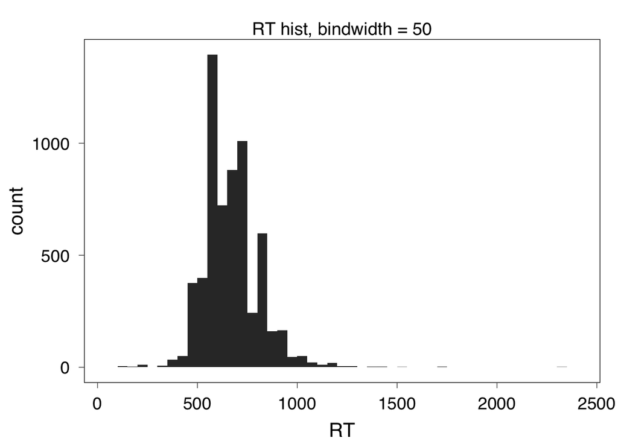

```r
qplot(data=d,x=RT,geom='histogram',binwidth=50)+
  ggtitle('RT hist, bindwidth = 50')
```

Challenge question: what is the sample rate of the input device they are using to gather RTs?

```r
gcd <- function(x,y) {
  r <- x%%y;
  return(ifelse(r, gcd(y, r), y))
}


as.integer(levels(factor(d$RT)))
```

```
##  [1]  101  107  140  175  176  212  213  248  315  316  317  352  353  383
## [15]  384  385  419  420  421  455  456  457  491  492  493  523  524  525
## [29]  559  560  561  595  596  597  627  628  629  663  664  665  699  700
## [43]  701  735  736  737  767  768  769  803  804  805  839  840  841  871
## [57]  872  873  907  908  909  943  944  945  975  976  977 1011 1012 1013
## [71] 1047 1048 1049 1084 1085 1115 1116 1117 1151 1152 1153 1187 1188 1189
## [85] 1219 1220 1255 1256 1257 1292 1359 1360 1431 1432 1433 1536 1708 2336
```

MH: I thought I could look at the lowest common denominator, but then the first entry `101` is prime, which suggests there is some rounding going on.

Sklar et al. did two manipulation checks. Subjective - asking participants whether they saw the primes - and objective - asking them to report the parity of the primes (even or odd) to find out if they could actually read the primes when they tried. Examine both the unconscious and conscious manipulation checks (this information is stored in subinfo). What do you see? Are they related to one another?

```r
summary(d$subjective.test)
```

```
##    Min. 1st Qu.  Median    Mean 3rd Qu.    Max.
##     0.0     0.0     0.5     0.5     1.0     1.0
```

```
## stat_bin: binwidth defaulted to range/30. Use 'binwidth = x' to adjust this.
```

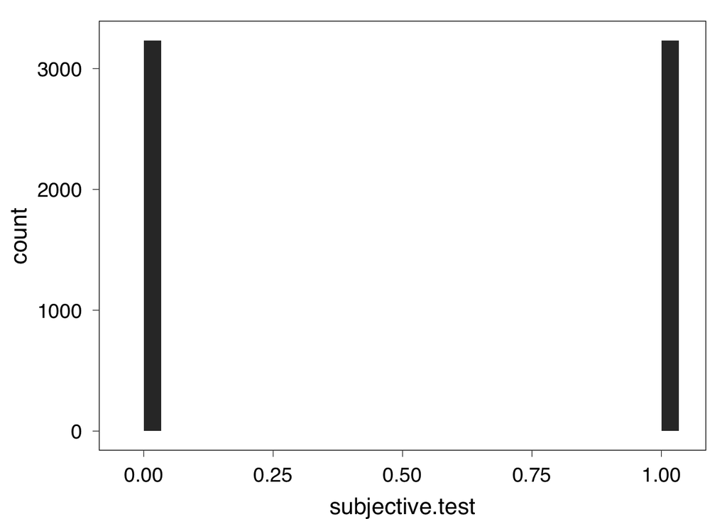

```r
qplot(subjective.test,data=d)
```

```r
summary(d$objective.test)
```

```
##    Min. 1st Qu.  Median    Mean 3rd Qu.    Max.
##   0.359   0.524   0.599   0.648   0.797   1.000
```

```
## stat_bin: binwidth defaulted to range/30. Use 'binwidth = x' to adjust this.
```

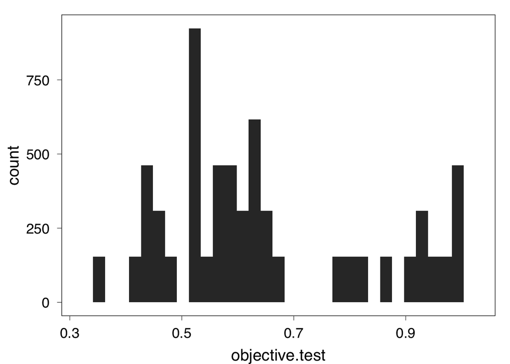

```r
qplot(objective.test,data=d)
```

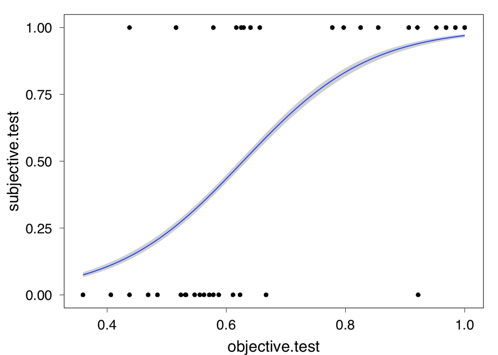

```r
qplot(objective.test, subjective.test, data =d)+
  stat_smooth(method="glm", family="binomial")
```

```r
summary(lm(objective.test~subjective.test, data=d)) # seem to be related
```

```
##
## Call:
## lm(formula = objective.test ~ subjective.test, data = d)
##
## Residuals:
##     Min      1Q  Median      3Q     Max
## -0.3162 -0.1130 -0.0032  0.0802  0.3791
##
## Coefficients:
##                 Estimate Std. Error t value Pr(>|t|)
## (Intercept)      0.54276    0.00261     208   <2e-16 ***
## subjective.test  0.21089    0.00370      57   <2e-16 ***
## ---
## Signif. codes:  0 '***' 0.001 '**' 0.01 '*' 0.05 '.' 0.1 ' ' 1
##
## Residual standard error: 0.149 on 6466 degrees of freedom
## Multiple R-squared:  0.335,  Adjusted R-squared:  0.335
## F-statistic: 3.25e+03 on 1 and 6466 DF,  p-value: <2e-16
```

MH: The two are related to one another.

OK, let’s turn back to the measure and implement Sklar et al.’s exclusion criterion. You need to have said you couldn’t see (subjective test) and also be not significantly above chance on the objective test (< .6 correct). Call your new data frame `ds`.

```r
ds<- d %>%
  filter(objective.test < 0.6 & subjective.test == 0)
```

## Sklar et al.’s analysis

Sklar et al. show a plot of a “facilitation effect” - the time to respond to incongruent primes minus the time to respond to congruent primes. They then show plot this difference score for the subtraction condition and for the two presentation times they tested. Try to reproduce this analysis.

HINT: first take averages within subjects, then compute your error bars across participants, using the `sem` function (defined above).

```r
ds.means <- ds %>%
  group_by(subid,congruent,operand,presentation.time) %>%
  summarise(m = mean(RT, na.rm=T)) %>%
  spread(congruent, m) %>%
  mutate(diff = no - yes) %>%
  select(-no,-yes) %>%
  group_by(operand,presentation.time) %>%
  summarise(groupm = mean(diff), sterr=sem(diff))
```

Now plot this summary, giving more or less the bar plot that Sklar et al. gave (though I would keep operation as a variable here. Make sure you get åsome error bars on there (e.g. `geom_errorbar` or `geom_linerange`).

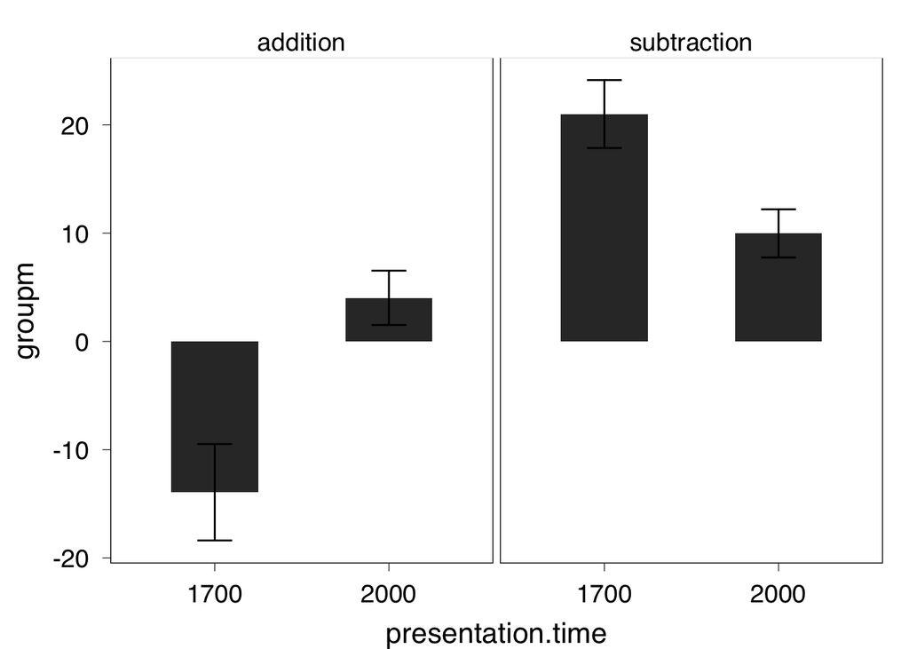

```r
ggplot(data=ds.means,
       aes(x = presentation.time,
           y = groupm))+
  geom_bar(position='identity',stat='identity', width=0.5)+
  geom_errorbar(aes(ymin= groupm-0.5*sterr,
                    ymax=groupm+0.5*sterr),
                width=0.2)+
  facet_wrap(~operand)
```

What do you see here? How close is it to what Sklar et al. report? Do the error bars match? How do you interpret these data?

MH: Their error bars are 0.5 * standard error.

Challenge problem: verify Sklar et al.’s claim about the relationship between RT and the objective manipulation check.

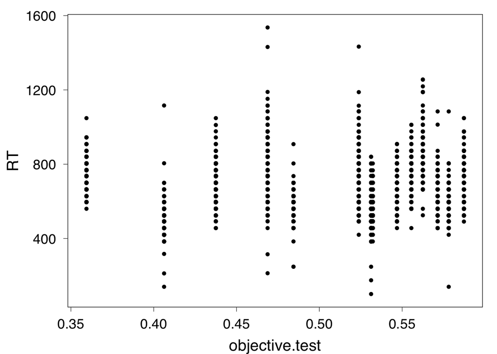

```r
ggplot(data=ds, aes(y=RT,x=objective.test))+
  geom_point()
```

```r
with(ds,cor(RT,objective.test,use="pairwise.complete.obs")) # no correlation
```

```
## [1] 0.04044
```

## Your own analysis

Show us what you would do with these data, operating from first principles. What’s the fairest plot showing a test of Sklar et al.’s original hypothesis that people can do arithmetic “non-consciously”?

[output not shown]

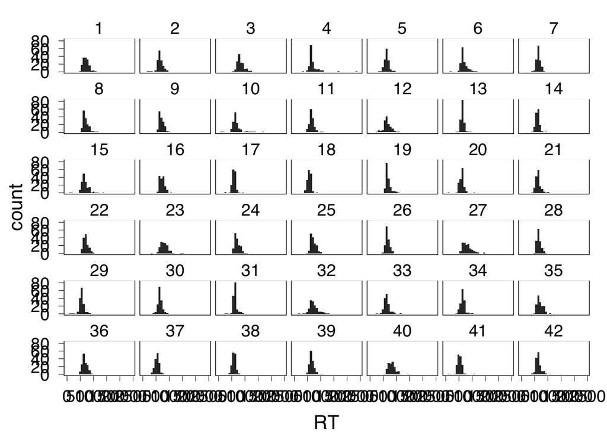

```r
ggplot(data = d, aes(x=RT))+
  geom_histogram()+
  facet_wrap(~subid)
```

RT histogram for each subject. Everyone is reasonably well behaved.

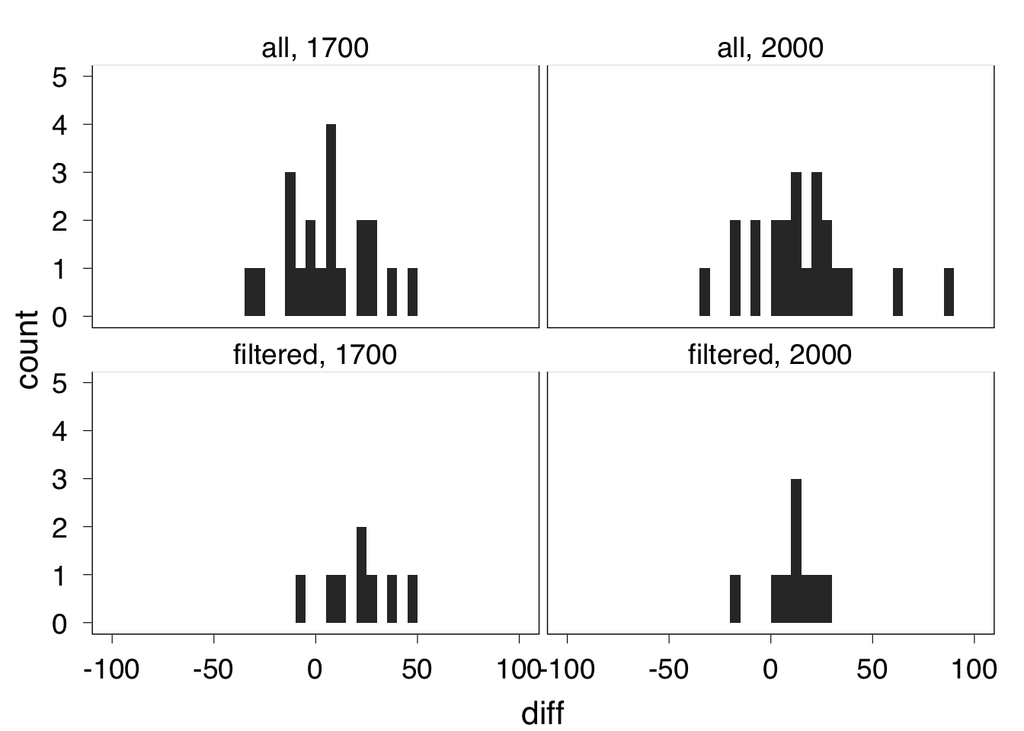

```r
ds.means1 <- d %>%
  group_by(subid,congruent,operand,presentation.time) %>%
  summarise(m = mean(RT, na.rm=T)) %>%
  spread(congruent, m) %>%
  mutate(diff = no - yes) %>%
  select(-no,-yes)


ds.means2 <- ds %>%
  group_by(subid,congruent,operand,presentation.time) %>%
  summarise(m = mean(RT, na.rm=T)) %>%
  spread(congruent, m) %>%
  mutate(diff = no - yes) %>%
  select(-no,-yes)

ds.means1$cat <- 'all'
ds.means2$cat <- 'filtered'

ds.m<-bind_rows(ds.means1,ds.means2)

ggplot(data = subset(ds.m,operand=='subtraction'), aes(x=diff))+
  facet_wrap(cat~presentation.time, scales='fixed')+
  geom_histogram(binwidth=5)+
  xlim(-100,100)+
  ylim(0,5)
```

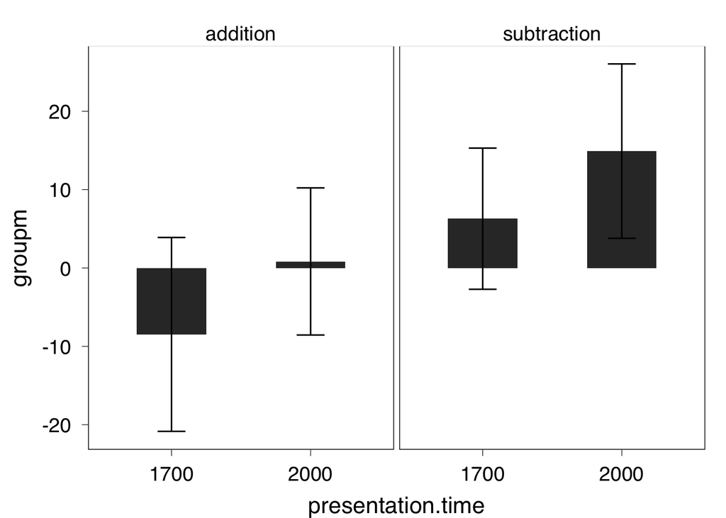

```r
ds.means <- d %>%
  group_by(subid,congruent,operand,presentation.time) %>%
  summarise(m = mean(RT, na.rm=T)) %>%
  spread(congruent, m) %>%
  mutate(diff = no - yes) %>%
  select(-no,-yes)%>%
  group_by(operand,presentation.time) %>%
  summarise(groupm = mean(diff), sterr=sem(diff))

ggplot(data=ds.means,
       aes(x = presentation.time,
           y = groupm))+
  geom_bar(position='identity',stat='identity', width=0.5)+
  geom_errorbar(aes(ymin= groupm-1.96*sterr,
                    ymax=groupm+1.96*sterr),
                width=0.2)+
  facet_wrap(~operand)
```